# EasyVisa Project

The overall trend is observed in certified cases with higher prevailing wages than denied ones, thus giving an indication of the probability of getting certified if the wages are high.

*Question 6*

What is the Percentage of visa certifications across each region?

```
case_status           Certified  Denied    All
region_of_employment
All                       17018    8462  25480
Northeast                  4526    2669   7195
West                       4100    2486   6586
South                      4913    2104   7017
Midwest                    3253    1054   4307
Island                      226     149    375
------------------------------------------------------------------------------------------------------------------------
```

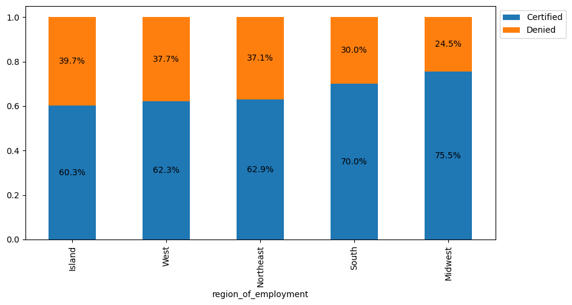

```python
## Code for stacked barplot for region of employment and case status
stacked_barplot(data, 'region_of_employment', "case_status")
```

*Observations*

Midwest has the highest certification rate of 75.5%, followed by South, then Northeast, then West, then Island.

The variation in the certified cases across various regions could be explained by various factors such as demand for skilled foreign workers in specific industries where there's shortage of local talent, state and local immigration policies, among others

*Question 7*

Is the prevailing wage similar across all the regions of the US?

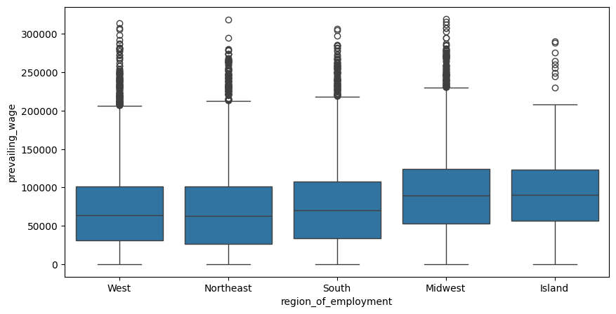

```python
## Code to create boxplot for region of employment and prevailing wage
plt.figure(figsize=(10, 5))
sns.boxplot(data=data, x="region_of_employment", y="prevailing_wage")
plt.show()
```

*Observations*

All regions show a significant number of outliers at the upper end, indicating higher wages in specific cases.

Prevailing wages are generally consistent across West, Northeast, and South regions.

Prevailing wages in the Midwest and Island regions are slightly higher in comparison with other regions.

*Question 8*

Do the employees who have prior work experience require any job training?

```
requires_job_training      N     Y    All
has_job_experience
All                    22525  2955  25480
N                       8988  1690  10678
Y                      13537  1265  14802
------------------------------------------------------------------------------------------------------------------------
```

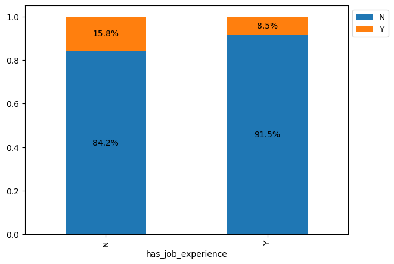

```python
## Code for stacked barplot for job experience and requires_job_training
stacked_barplot(data, 'has_job_experience', "requires_job_training")
```

*Observations*

Vast majority (91.5%) with job experience require no training. They may be well- equipped for their roles. However, 8.5% might require some job training to equip them with specific skills or knowledge for their current roles.

## Data Preprocessing

- Missing value treatment (if needed)
- Feature engineering
- Outlier detection and treatment (if needed)
- Preparing data for modeling
- Any other preprocessing steps (if needed)

### Checking for Missing value

```python
data.isnull().sum()
```

|  | 0 |
| --- | --- |
| continent | 0 |
| education_of_employee | 0 |
| has_job_experience | 0 |
| requires_job_training | 0 |
| no_of_employees | 0 |
| yr_of_estab | 0 |
| region_of_employment | 0 |
| prevailing_wage | 0 |
| unit_of_wage | 0 |
| full_time_position | 0 |
| case_status | 0 |

**dtype:** int64

*Observations*

No missing value in the dataset

### Outlier Check

- Let's check for outliers in the data.

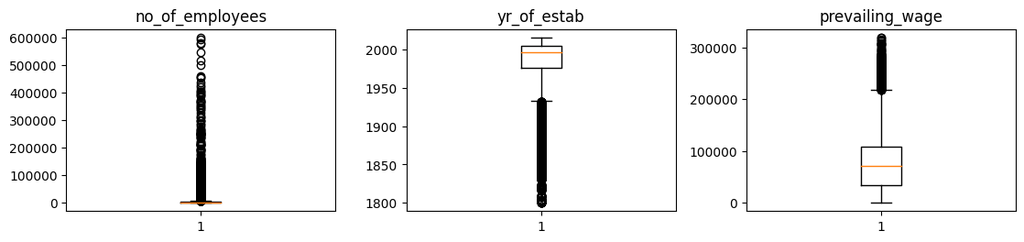

```python
# outlier detection using boxplot
numeric_columns = data.select_dtypes(include=np.number).columns.tolist()
 ## Let us create boxplots for all the numeric columns
plt.figure(figsize=(15, 12))

for i, variable in enumerate(numeric_columns):
    plt.subplot(5, 4, i + 1)
    # boxplot
    plt.boxplot(data[variable], whis=1.5)
    # plot layout
    plt.tight_layout()
    # plot title
    plt.title(variable)
# show the plot
plt.show()
```

*Observations*

There are significant outliers in the dataset. These are proper values which would require no treatment.

### Data Preparation for modeling

- We want to predict which visa will be certified.
- Before we proceed to build a model, we'll have to encode categorical features.
- We'll split the data into train and test to be able to evaluate the model that we build on the train data.

```python
data["case_status"] = data["case_status"].apply(lambda x: 1 if x == "Certified" else 0)
## Complete the code to drop case status from the data
X = data.drop(["case_status"], axis=1)
y = data["case_status"]

## Complete the code to create dummies for X
X = pd.get_dummies(X, drop_first=True)

## Let's split the data into train and test in the ratio 70:30
# Splitting data in train and test sets
X_train, X_test, y_train, y_test = train_test_split(X, y, test_size=0.3, random_state=1, stratify=y)
```

```python
print("Shape of Training set : ", X_train.shape)
print("Shape of test set : ", X_test.shape)
print("Percentage of classes in training set:")
print(y_train.value_counts(normalize=True))
print("Percentage of classes in test set:")
print(y_test.value_counts(normalize=True))
```

```
Shape of Training set :  (17836, 21)
Shape of test set :  (7644, 21)
Percentage of classes in training set:
1    0.667919
0    0.332081
Name: case_status, dtype: float64
Percentage of classes in test set:
1    0.667844
0    0.332156
Name: case_status, dtype: float64
```

## Model evaluation criterion

### Model can make wrong predictions as:

1. Model predicts that the visa application will get certified but in reality, the visa application should get denied.
2. Model predicts that the visa application will not get certified but in reality, the visa application should get certified.

### Which case is more important?

- Both the cases are important as:
- If a visa is certified when it had to be denied a wrong employee will get the job position while US citizens will miss the opportunity to work on that position.
- If a visa is denied when it had to be certified the U.S. will lose a suitable human resource that can contribute to the economy.

### How to reduce the losses?

- `F1 Score` can be used a the metric for evaluation of the model, greater the F1 score higher are the chances of minimizing False Negatives and False Positives.
- We will use balanced class weights so that model focuses equally on both classes.

**First, let's create functions to calculate different metrics and confusion matrix so that we don't have to use the same code repeatedly for each model.**

- The model_performance_classification_sklearn function will be used to check the model performance of models.
- The confusion_matrix_sklearn function will be used to plot the confusion matrix.

```python
# defining a function to compute different metrics to check performance of a classification model built using sklearn


def model_performance_classification_sklearn(model, predictors, target):
    """
    Function to compute different metrics to check classification model performance

    model: classifier
    predictors: independent variables
    target: dependent variable
    """

    # predicting using the independent variables
    pred = model.predict(predictors)

    acc = accuracy_score(target, pred)  # to compute Accuracy
    recall = recall_score(target, pred)  # to compute Recall
    precision = precision_score(target, pred)  # to compute Precision
    f1 = f1_score(target, pred)  # to compute F1-score

    # creating a dataframe of metrics
    df_perf = pd.DataFrame(
        {"Accuracy": acc, "Recall": recall, "Precision": precision, "F1": f1,},
        index=[0],
    )

    return df_perf
```

```python
def confusion_matrix_sklearn(model, predictors, target):
    """
    To plot the confusion_matrix with percentages

    model: classifier
    predictors: independent variables
    target: dependent variable
    """
    y_pred = model.predict(predictors)
    cm = confusion_matrix(target, y_pred)

    # Check if cm is 1x1, if yes, convert to 2x2 with necessary adjustments
    if cm.shape == (1, 1):
        if cm[0, 0] == target.sum():  # all predicted as class 1
            cm = np.array([[cm[0, 0], 0], [0, 0]])
        else:  # all predicted as class 0
            cm = np.array([[0, 0], [0, cm[0, 0]]])

    labels = np.asarray(
        [
            ["{0:0.0f}".format(item) + "\n{0:.2%}".format(item / cm.flatten().sum())]
            for item in cm.flatten()
        ]
    ).reshape(2, 2)

    plt.figure(figsize=(6, 4))
    sns.heatmap(cm, annot=labels, fmt="")
    plt.ylabel("True label")
    plt.xlabel("Predicted label")
```